# LK1 re-sequenced

260522_VH01624_461_222JLJVNX

2026-08-03

**Run:** `260522_VH01624_461_222JLJVNX` (re-sequencing of `260423_VH01624_453_222HWMYNX`)

**Status:** current. This is the LK1 data used by all later analyses; the pilot run `260423_VH01624_453_222HWMYNX` it replaces is superseded.

**Analysis finished:** 2026-06-01 - the most recent of the 13 figures shown below.

**Report generated:** 2026-08-03 by `05.LK1_resequenced_report.Rmd`, from the outputs of steps 01-04 in this folder.

LK1 was sequenced a second time to decide whether the pilot depth was sufficient, and whether the rest of the cohort needed deeper sequencing. The comparison is against the pilot run and against the published AML scAtlas.

For full report, download `LK1_resequenced_report.html` in the attachment and open in a browser.

Code used - attached and in the github repository: https://github.com/nbartonicek/surface_proteome_dev/tree/main/lab_archives/LK1-resequenced

# Aim

Identify whether we are getting a comparable amount of key features to the AML scAtlas - cells, genes and UMIs - and evaluate whether further sequencing is required, via:

- subsampling of reads
- differential expression between cell types
- separation of clusters

# Conclusions

- AML scAtlas basic QC stats are comparable to our dataset, on average lower
- subsampling of reads shows that we have reached saturation levels for cell detection
- we have **not** reached saturation levels for: number of genes detected; number of UMIs per gene; number of DE genes for cells with either low (T-cells) or high (HSCs) numbers of genes expressed
- cluster separation of HSCs from other precursors (MEP) is slightly better for re-sequenced data
- re-sequencing gained about 25% more genes and 39% more UMIs per cell for essentially no extra cells, which is the expected shape when a library is under-sequenced rather than under-loaded

# 1. What re-sequencing gained

First run vs re-sequenced, per-cell gain

| name | first_run | resequenced | absolute_gain | fold_gain |
| --- | --- | --- | --- | --- |
| median_genes | 2052.000 | 2562.000 | 510.0000 | 1.248538 |
| median_UMI | 4202.000 | 5833.000 | 1631.0000 | 1.388149 |
| mean_genes | 2595.986 | 3095.429 | 499.4427 | 1.192390 |
| mean_UMI | 8396.377 | 11630.430 | 3234.0527 | 1.385172 |

Our two runs against the AML scAtlas

| dataset | cells | median_genes | mean_genes | p10_genes | p90_genes | median_UMI | mean_UMI | p10_UMI | p90_UMI |
| --- | --- | --- | --- | --- | --- | --- | --- | --- | --- |
| AML scAtlas | 748679 | 1611 | 1801.281 | 690 | 3228 | 2195.882 | 2158.776 | 1448.527 | 2829.167 |
| first_run | 23133 | 2052 | 2595.986 | 920 | 5539 | 4202.000 | 8396.377 | 1479.000 | 24312.400 |
| resequenced | 23569 | 2562 | 3095.429 | 1115 | 6393 | 5833.000 | 11630.430 | 1892.800 | 34087.000 |

Both runs sit **above** the atlas medians on genes and UMIs per cell, which is what “atlas stats are on average lower” in the conclusions refers to.

Cell Ranger metrics, both runs

| Estimated Number of Cells | Mean Reads per Cell | Median Genes per Cell | Number of Reads | Sequencing Saturation |
| --- | --- | --- | --- | --- |
| 23569 | 29125 | 2562 | 686439168 | 46.5% |
| 23133 | 20537 | 2052 | 475071355 | 45.0% |

Sequencing saturation stays in the mid-40s in both runs - consistent with the curves below, where cell detection has plateaued but per-cell content has not.

**`median_genes_barplot.pdf`**

Median genes per cell, first run vs re-sequenced.

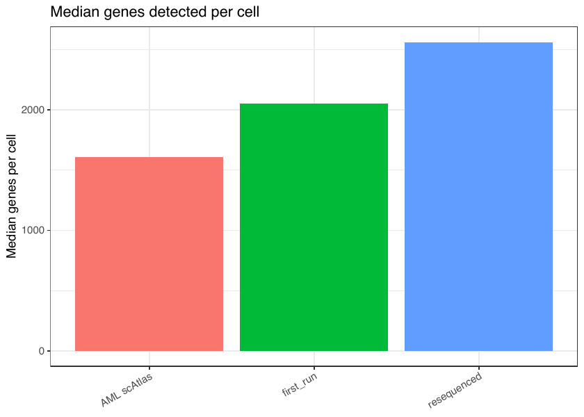

**`median_UMIs_barplot.pdf`**

Median UMIs per cell, first run vs re-sequenced.

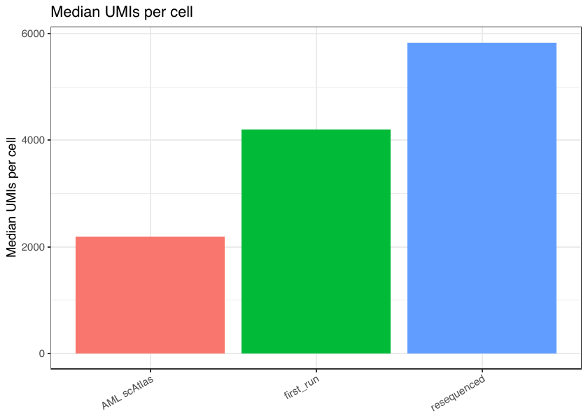

**`combined_benchmark_plot.pdf`**

Combined benchmark across both runs and the atlas.

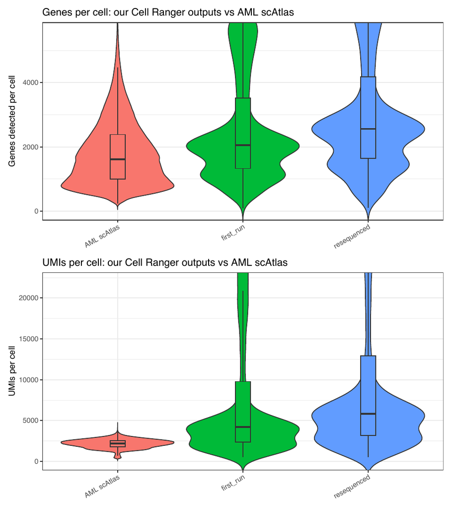

# 2. Against the AML scAtlas

**`comparison_genes_vs_AML_atlas.pdf`**

Genes per cell, our runs against the atlas.

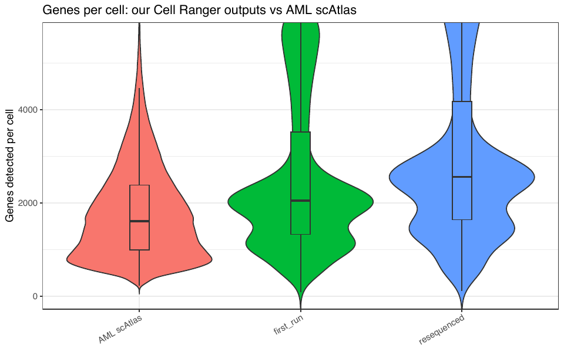

**`comparison_UMIs_vs_AML_atlas.pdf`**

UMIs per cell, our runs against the atlas.

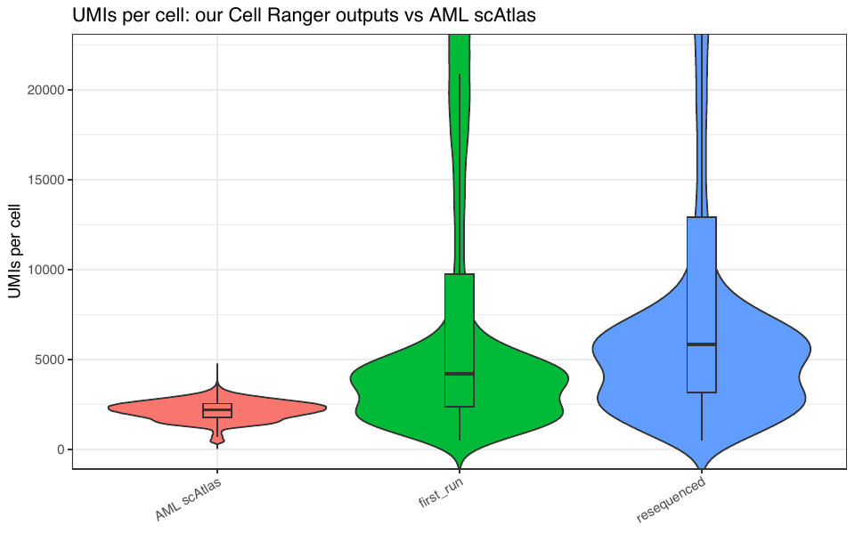

**`violin_genes_UMIs_per_cell_full_depth_vs_AML_10x3v3.pdf`**

Restricted to 10X 3’ v3, the assay that matches ours - the fair comparison, since the atlas pools several chemistries with different capture efficiency.

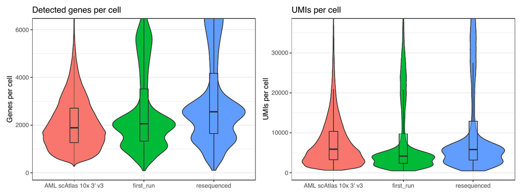

**`barplot_cell_counts_by_cell_type.pdf`**

Atlas cell counts by cell type, for context on what the reference contains.

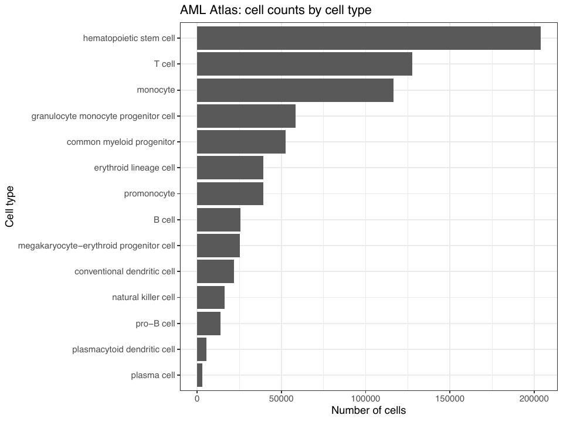

**`boxplot_cells_per_donor_by_assay.pdf`**

Cells per donor by assay in the atlas.

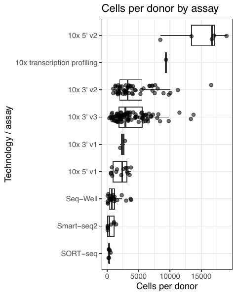

# 3. Saturation curves

Cell Ranger’s molecule-level downsampling, re-analysed at each depth and plotted against the atlas. These are the figures the saturation conclusions rest on.

**`curve_cells_detected_vs_AML.pdf`**

**Cells detected vs depth - this one has plateaued.** Extra reads do not recover extra cells.

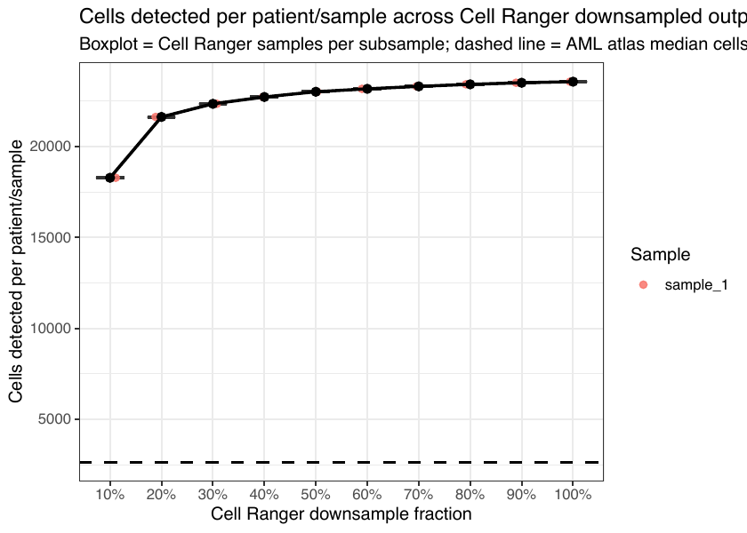

**`curve_genes_per_cell_vs_AML.pdf`**

**Genes per cell vs depth - still climbing.** No plateau, so more depth would still add genes.

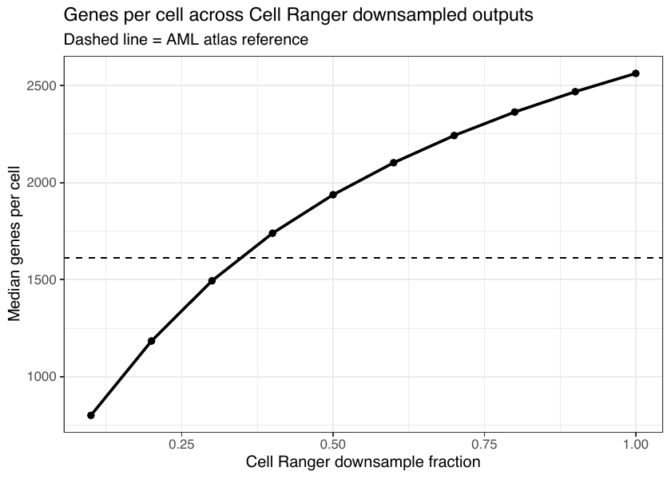

**`curve_UMIs_per_gene_vs_AML.pdf`**

**UMIs per gene vs depth - still climbing.**

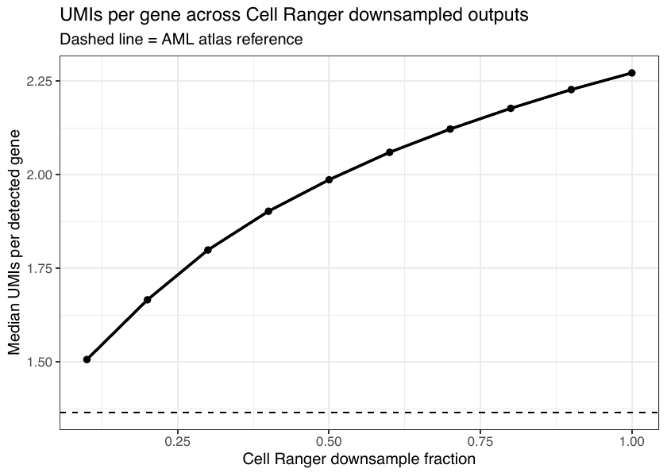

**`curve_UMIs_per_cell_vs_AML.pdf`**

UMIs per cell vs depth.

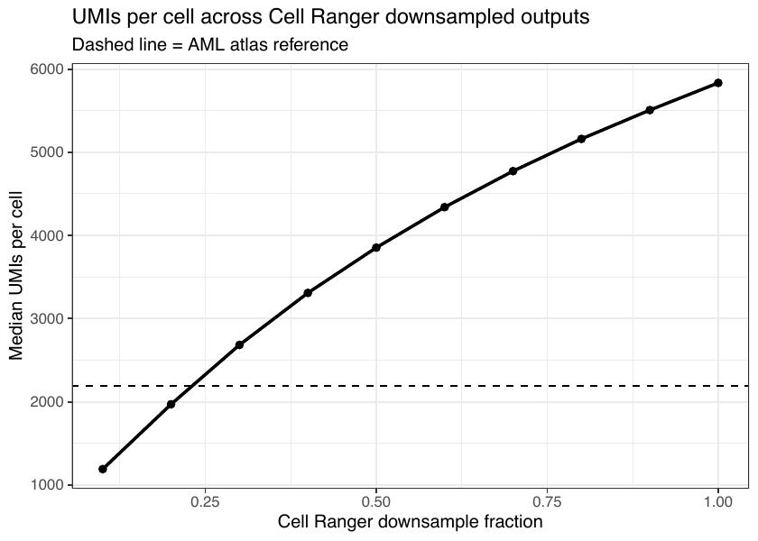

**`curve_reads_per_cell.pdf`**

Reads per cell across the depth series.

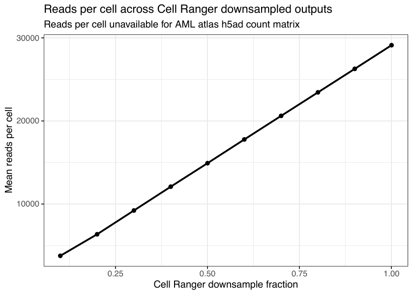

# 4. Effect of depth on downstream analysis

Two things were checked beyond raw counts: whether differential expression between cell types holds up at lower depth, and whether clusters still separate.

| Depth | Total clusters | HSC clusters |
| --- | --- | --- |
| 10% subsample | 5 | 2 |
| 30% subsample | 8 | 3 |
| 60% subsample (~pilot 1) | 8 | 4 |
| Full dataset | 9 | 4 |

The full dataset resolves one cluster the 60% subsample does not - naive T-cells - and HSC separation from other precursors improves with depth. The pilot run sits at roughly the 60% point of the re-sequenced data, which is why its HSC/MEP separation is the weaker of the two.

# 5. Data locations

| What | Location |
| --- | --- |
| Sequencing facility output | `/pipeline/Runs/NextSeq/260522_VH01624_461_222JLJVNX/ProjectFolders/Project_Lev-Kats` |
| Working copy, cluster | `/scratch/users/nbartonicek/projects/amgen/raw_reseq/260522_VH01624_461_222JLJVNX` - `Sample_LK1-GEX/` |
| Cell Ranger output | `/scratch/users/nbartonicek/projects/amgen/results/cellranger_withbam/260522_VH01624_461_222JLJVNX` |
| Depth benchmarking | `results/benchmarking/depth_benchmarking/` and `.../depth_benchmarking_cellranger_downsampled/` |
| Reference | Cell Ranger annotation `refdata-gex-GRCh38-2024-A` |

Table: Output directories under results/

/260522_VH01624_461_222JLJVNX (top-level entries)

| directory | entries | first | last |
| --- | --- | --- | --- |
| cellranger_withbam | 1 | 2026-06-25 | 2026-06-25 |
| cite_seq_count | 3 | 2026-06-03 | 2026-07-08 |
| emptydrops | 2 | 2026-06-02 | 2026-06-02 |
| genotype_demux | 2 | 2026-06-02 | 2026-06-02 |
| scDblFinder | 1 | 2026-06-02 | 2026-06-02 |
| seurat_demux | 6 | 2026-06-02 | 2026-06-09 |
| cellbender | 1 | 2026-06-24 | 2026-06-24 |

The re-sequenced run was then taken through the standard processing - emptyDrops, CITE-seq-Count, cellSNP/vireo, scDblFinder, CellBender. Those steps are benchmarked in their own reports rather than here; this one covers the re-sequencing decision only.

# 6. What was run, in order

| Step | Script | What it does |
| --- | --- | --- |
| 01 | `01.cellranger_resequence.sh` | Cell Ranger 10.0.0 count on the re-sequenced LK1 GEX library. |
| 02 | `02.investigate_resequencing.R` | First run vs re-sequenced: cells, genes, UMIs, and the gain summary. |
| 03 | `03.subsampling_vs_atlas.R` | Our depth against the AML scAtlas, plus the molecule-level saturation curves. |
| 04 | `04.DE_subsampling.R` | Pseudobulk DE at each depth, then cluster HBDN501-AML-KMT2A and score separation. |
| 05 | `05.LK1_resequenced_report.Rmd` | This report. |

Each analysis appears once. Where a script went through successive revisions, the version kept is the one that produced the outputs shown, and its header names the revisions it supersedes:

[output not shown]

# 7. Tools

| Tool | Version | Source |
| --- | --- | --- |
| Cell Ranger | 10.0.0 | `~/tools/cellranger-10.0.0/cellranger` - the re-sequencing needed this version |
| Cell Ranger annotation | `refdata-gex-GRCh38-2024-A` | `annotation/` |
| AML scAtlas | published reference | `results/AML_atlas/` |

# 8. Caveats